# A two-dimensional integrand with a diagonal ridge

This document looks the performance of the serial CUHRE and VEGAS algorithms on a function that has a diagnoal ridge.

Marc Paterno https://github.com/marcpaterno  
12-15-2020

## Purpose of this analysis

The serial VEGAS algorithm typically is challenged by integrands that are not separable, and which contain ridges that are not aligned with the coordinate axes. This analysis uses such an integrand to demonstrate this issue.

The integrand chosen is:
$$\frac{4 k u^2}{\frac{1}{100}+\left(u-v -\frac{1}{3}\right)^2}$$
with
$$k = 4050 / \left(43200+14920 \pi -125840 \tan^{-1}(\frac{3}{70})-14920 \tan^{-1}(\frac{3}{50})+110920 \tan^{-1}(\frac{3}{10})+ \\
54000 \tan^{-1}(\frac{50}{3})+54000 \tan^{-1}(\frac{70}{3})+17946 \log(109)-3573 \log(2509)-14373 \log(4909) \right).$$
The approximate value of $k$ is 0.01890022674239546529975841.

The volume of integration is (-1, 1) for both $x$ and $y$. The correct value of the integral is 1.

## Testing environment

These tests were run on a MacBook Pro laptop.

The MacBook machine used in these tests has a single 4-core 2.9 GHz Intel Core i7 processor.

## Description of the dataframe

1. *alg*: the name of the algorithm
2. *epsrel*: the fractional error target
3. *value*: the estimated value of the integral
4. *errorest*: the estimated error for the result
5. *error*: the absolute difference between the estimated value and the true value
6. *neval*: the number of function evaluations used
7. *nregions*: the number of regions used
8. *time*: the time in milliseconds for the calculation
9. *r*: ratio of (errorest/(epsrel*value)); this should be less than 1 if the algorithm has converged
10. *converged*: boolean showing whether r < 1

A value of NA indicates that the algorithm did not converge, but rather stopped because the maximum number of function evaluations had been reached.

| alg | epsrel | value | errorest | error | neval | nregions | time | r | converged |
| --- | --- | --- | --- | --- | --- | --- | --- | --- | --- |
| cuhre_0 | 1.000000e-01 | 0.9977761 | 9.108339e-02 | 2.223873e-03 | 1625 | 13 | 0.052925 | 0.9128640 | TRUE |
| cuhre_1 | 1.000000e-01 | 1.0003796 | 8.773455e-02 | 3.795723e-04 | 2405 | 19 | 0.061037 | 0.8770126 | TRUE |
| vegas | 1.000000e-01 | 0.9893167 | 8.609000e-02 | 1.068335e-02 | 1000 | -1 | 0.080154 | 0.8701966 | TRUE |
| cuhre_0 | 5.000000e-02 | 0.9989338 | 4.945568e-02 | 1.066192e-03 | 2145 | 17 | 0.060905 | 0.9901693 | TRUE |
| cuhre_1 | 5.000000e-02 | 0.9998720 | 4.574030e-02 | 1.280443e-04 | 2925 | 23 | 0.070504 | 0.9149231 | TRUE |
| vegas | 5.000000e-02 | 1.0111065 | 3.714146e-02 | 1.110650e-02 | 2500 | -1 | 0.086027 | 0.7346695 | TRUE |
| cuhre_0 | 2.500000e-02 | 0.9999037 | 2.326547e-02 | 9.628031e-05 | 2925 | 23 | 0.076650 | 0.9307082 | TRUE |
| cuhre_1 | 2.500000e-02 | 1.0000666 | 2.320352e-02 | 6.657927e-05 | 3705 | 29 | 0.086290 | 0.9280790 | TRUE |
| vegas | 2.500000e-02 | 0.9990369 | 2.400607e-02 | 9.631217e-04 | 4500 | -1 | 0.117667 | 0.9611685 | TRUE |
| cuhre_0 | 1.250000e-02 | 0.9999987 | 1.233293e-02 | 1.314046e-06 | 3575 | 28 | 0.096923 | 0.9866361 | TRUE |

[output cut: 80 more lines]

## Analysis

As one measure of the innate “efficiency” of each algorithm, we consider how many function evaluations are required to obtain a given fractional error tolerance.

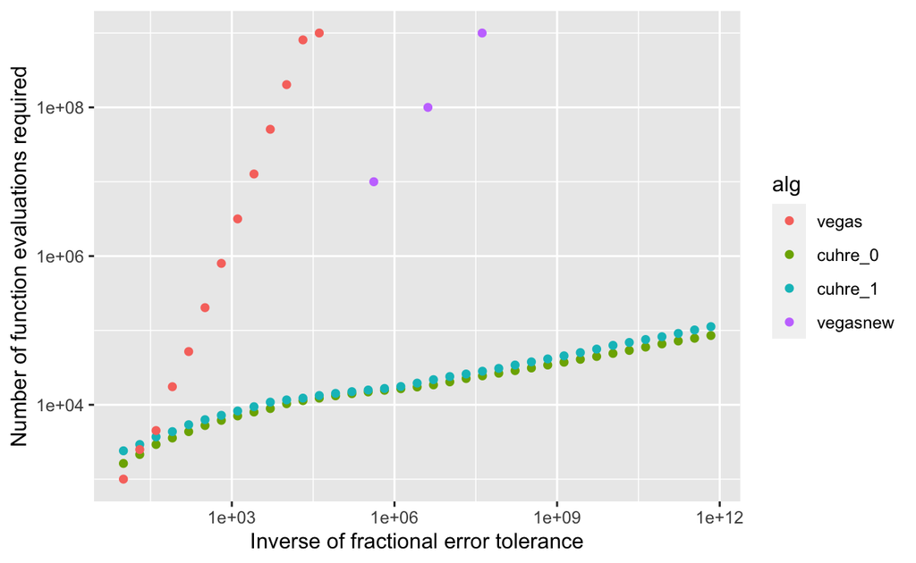

For this integrand, except at the very loosest tolerances VEGAS always requires more function calls than does CUHRE. CUHRE with flag=0 requires fewer function evaluations than it does with flag=4.

### Calculation time as a function of required error tolerance

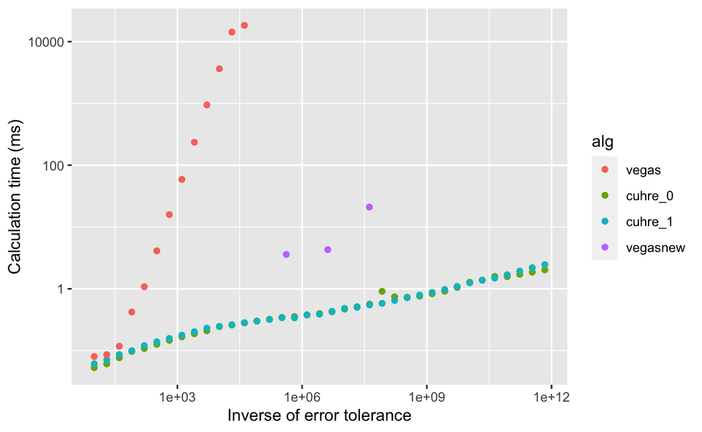

### Error estimate and function evaluations

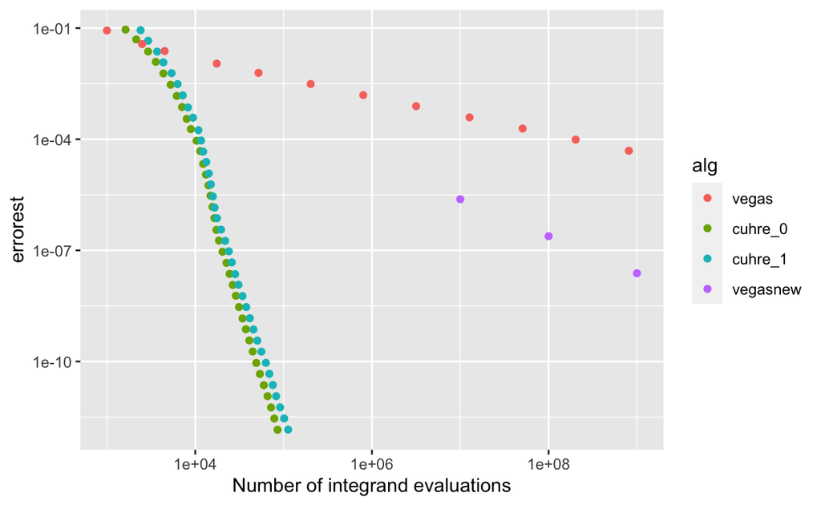

### Reliability of error estimate

If we look only at the calculations that converged, how accurate are the error estimates?

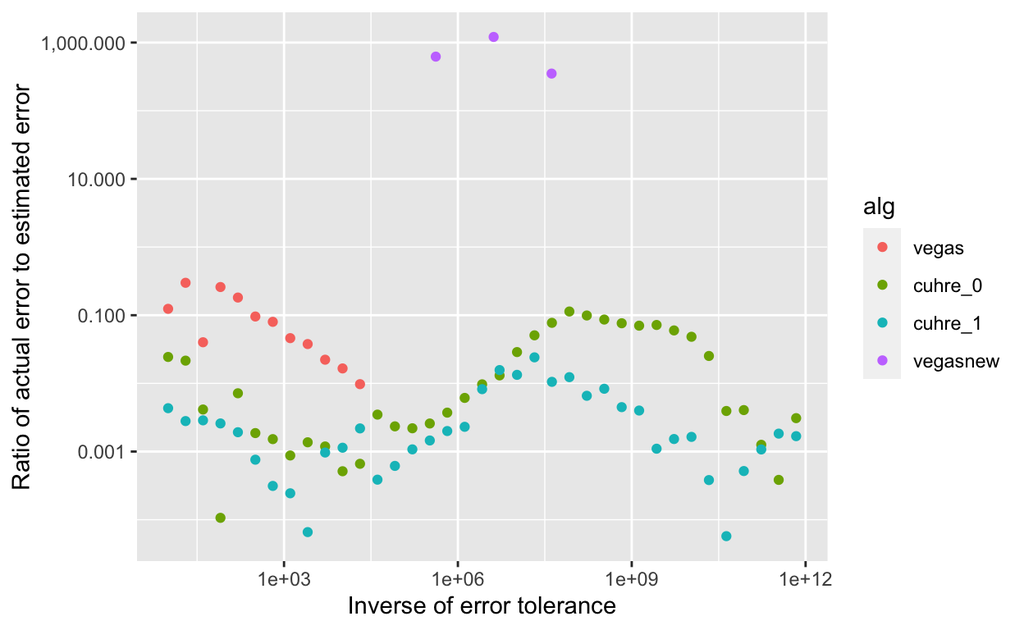

Users do not really care about the number of function evaluations done; they care about the time the algorithm takes to converge for a given error tolerance, and that the algorithm has actually converged to that tolerance.

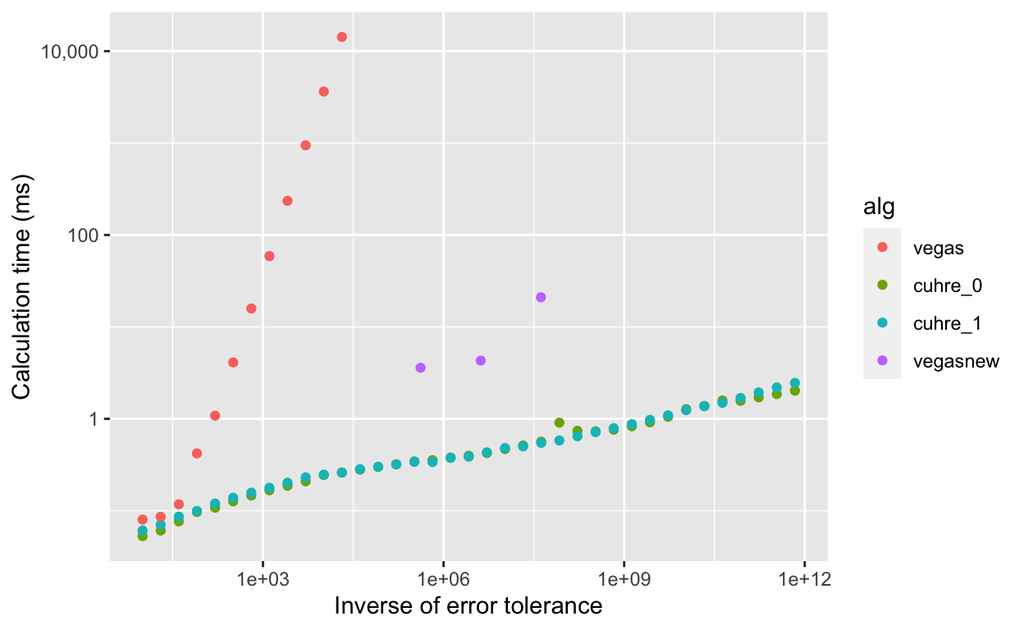

For this integrand, the CUHRE algorithm is much faster than VEGAS. There seems to be little performance difference between CUHRE with flag = 0 and flag = 4.

### Regions used by the CUHRE algorithm

It is remarkable how few regions the CUHRE algorithm needs to evaluate this integral with high accuracy.

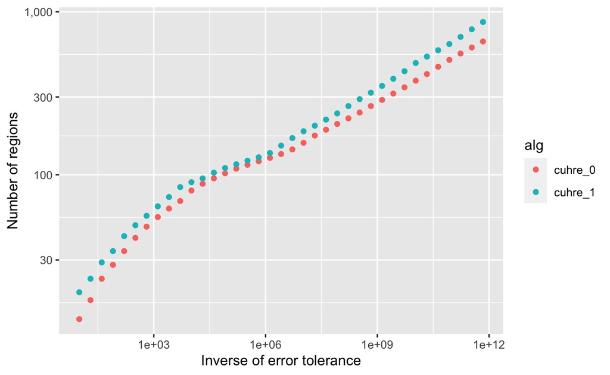

### Reliability of error estimate

One measure of the reliability of the error estimate is the ratio of the actual error to the error estimate. Since we know the true answer for this integral, we can plot this. We do so as a function of the number of function evaluations and as a function of the algorithm running time.

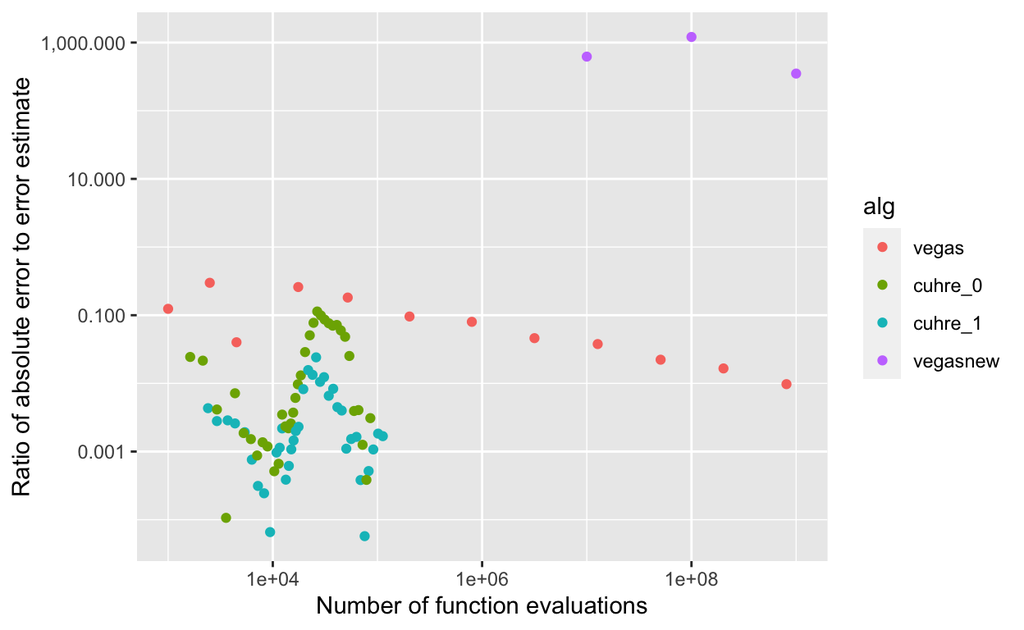

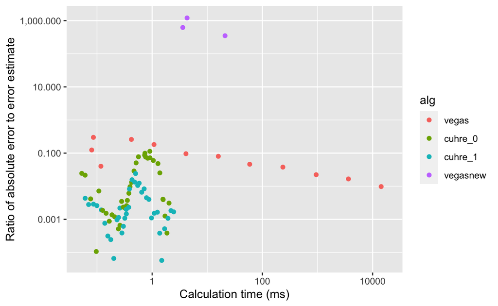

Another way to look at the reliability of the error estimate is to look at the variability of the estimated integral value as we increase the number of function evaluations, and to compare the error estimate to that variability. The following plot does this.

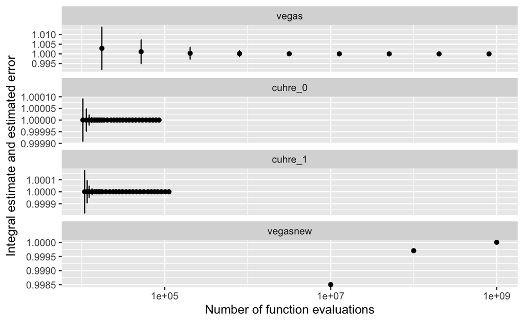

For *vegasnew*, the error estimates are very small, but the actual error in the result is much larger than the error estimate.

The dynamic range of the error estimates makes it difficult to discern the behavior of the algorithms when the error estimates become small.